# Regression Model Course - Course Project

Thiago Mata

29 January 2019

## Introduction

In this project, the goal is to make a study to the Motor Trend magazine that want know more about the relationship between a set of variables and miles per gallon (MPG) (outcome). The result should be presented as a [PDF](https://github.com/thiagomata/CourseraRegressionModelProject/blob/master/Project.pdf) created from a [Project R Markdown File](https://github.com/thiagomata/CourseraRegressionModelProject/blob/master/Project.Rmd) They are particularly interested in the following two questions:

- Is an automatic or manual transmission better for MPG
- Quantify the MPG difference between automatic and manual transmissions

## Analysis

As shown on the box plot, looking just to MPG and Type of Transmission seems to have a strong relationship between these two fields. So, different models are going to be created and compared to check this hypothesis.

With p-value of 0.8987 for Automatic Transmission Type and 0.5363 for Manual Transmission Type, we can assume that is a Normal Distribution and create linear models.

### Creating Regression Models

### Comparing Coeficients in Models

| model | expectedOutcome | predictors |
| --- | --- | --- |
| Model A | MPG | Just the Transmission Type |
| Model B | MPG | Fields strong correlated with the MPG, including Transmission Type |
| Model C | MPG | Fields strong correlated with the MPG, except Transmission Type |
| Model D | Transmission Type | Fields strong correlated with the Transmission Type, except MPG |
| Model E | Residuals of Model B | Just the Transmission Type |

| model | am | wt | vs | cyl | drat | hp | disp | RSS |
| --- | --- | --- | --- | --- | --- | --- | --- | --- |
| Model A | 7.2449 | NA | NA | NA | NA | NA | NA | 720.8966 |
| Model B | 1.9520 | -3.2453 | 1.3976 | -0.6399 | 0.5470 | -0.0303 | 0.0135 | 158.6543 |
| Model C | NA | -3.7231 | 0.5054 | -0.9765 | 1.0451 | -0.0238 | 0.0127 | 166.8170 |
| Model D | NA | -0.2448 | -0.4571 | -0.1724 | 0.2552 | 0.0033 | -0.0004 | 2.1422 |

As shown on the table above, some of the predictors of the Transmission Type (am), as Type of Engine (vs) and Weight (wt), are also predictors of the MPG. So, to have a clear vision about the influence of the Transmission Type on the MPG, let’s see how good is the Transmission Type to predict the residual.

So, we can see that the Transmission Type, have a strong impact on the prediction. When we remove it, the Residual sum of squares - RSS increases 4.89%. But, the influence of it on the MPG is not as big in the model that only consider that field. So, many other fields also have a strong influence over the MPG, and some of them are also strongly correlated with the Transmission Type.

So, the Type of Transmission is a good to predict if a car presents many features that, all together, increase the car consume. Considering the 95% of confidence interval, that effects may vary in the interval of 3.6415096 to 10.848369.

After extracting all the predictability data from the others fields, this new model can measure if the remain data is still correlated to the Type of Transmission. The coefficient from the Type of Transmission in this case is 0.5417548. After removing the influence of the others fields, the influence of the Type of Transmission on the MPG is 0.5417548 with residual squared error of 164.5515427. Considering the 95% of confidence interval, that effects may vary in the interval of -1.1798384 to 2.263348.

As we can see on the residual plot, using just the Transmission Type to try to predict the MPG have a strong RSS and is not a good model. Adding the Transmission Type, on the model reduce the Residual Sum of Squareds in 4.89%.

## Conclusion

If we don’t have any other information about a car, beyond the Type of Transmission, then knowing that a car has Manual Transmission should have the MPG around 7.2449393 (from 3.6415096 to 10.848369 in the 95% confidence interval) bigger than the Automatic. If we know everything about a car, and just changing the transmission type from Automatic to Manual shoud increase the MPG around 1.9520082 (from -1.6735479 to 5.5775643 in the 95% confidence interval).

So, automatic cars in general consume more than manual ones. But, not necessarly because the Type of Engine increase the consume. But, in general, automatic cars presents others features, that also affects the consume. Considering the Transmission Type isolated, the real effect of changing the Transmission Type is 0.5417548 MPG (from -1.1798384 to 2.263348 in the 95% confidence interval).

Considering our 95% confidence interval, there is a reasonable chance that the effect of the different types of Transmission Types is zero. In that sense, it **is inconclusive if some Transmission Type is better for MPG**. But, we still can say that, if the Transmission Type affects the MPG, the impact is pretty low (from -1.1798384 to 2.263348).

## Appendices

### Dataset

The dataset used in this study is the [Motor Trend Car Road Tests Data](https://www.rdocumentation.org/packages/datasets/versions/3.5.2/topics/mtcars). Each row contains the following fields:

| field | description | percent.of.Null |
| --- | --- | --- |
| mpg | Miles/(US) gallon | 0 % |
| cyl | Number of cylinders | 0 % |
| disp | Displacement (cu.in.) | 0 % |
| hp | Gross horsepower | 0 % |
| drat | Rear axle ratio | 0 % |
| wt | Weight (1000 lbs) | 0 % |
| qsec | 1/4 mile time | 0 % |
| vs | Type of Engine (0 = V-shaped 1 = straight) | 0 % |
| am | Type of Transmission (0 = automatic 1 = manual) | 0 % |
| gear | Number of forward gears | 0 % |
| carb | Number of carburetors | 0 % |

### Box Plot - Type of Transmission x MPG

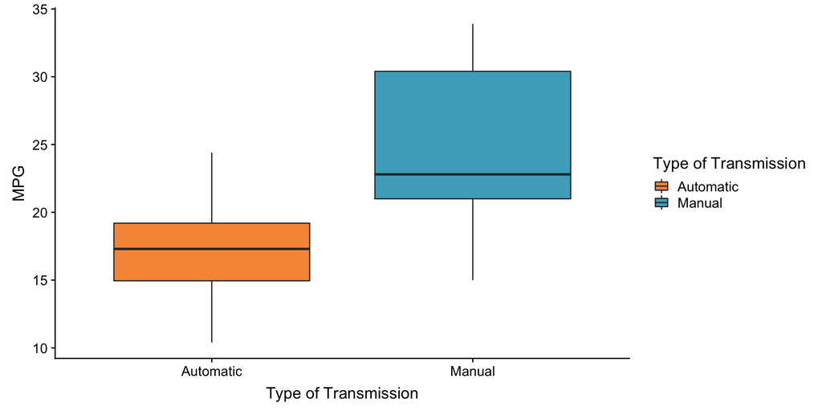

### Quantile-Quantile for Normality Check

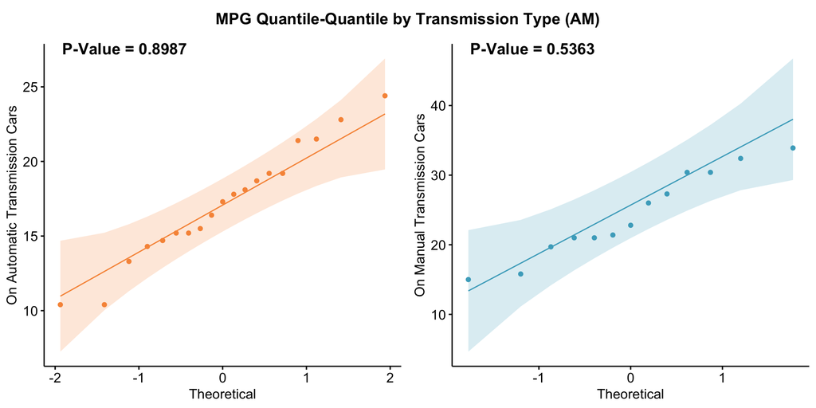

## Residuals of the Models

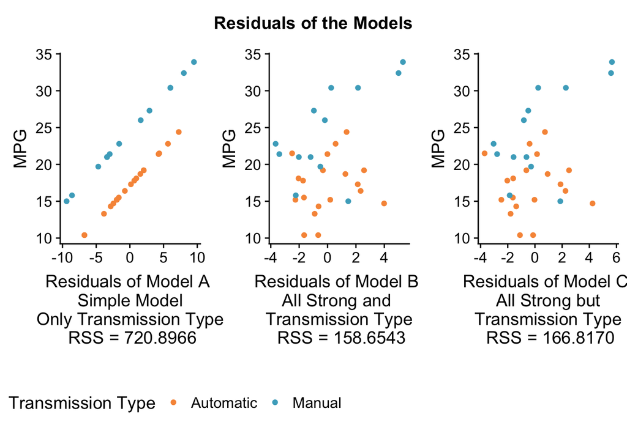